# NDExR and Cytoscape: Interactive and automated visualization of biological networks using R

Florian Auer

1 2 2018

# NDExR and Cytoscape: Interactive and automated visualization of biological networks using R

*Florian Auer, Frank Kramer, Tim Beißbarth* **University Medical Center Göttingen** *Abstract for a Talk at the Workshop on Computational Models in Biology and Medicine 2018 in Regensburg*

Network models form a simple and flexible way of representing diverse associations within complex systems, and its applications are well-established in a wide range of fields in biology. Within a common bioinformatics workflow data integration, network analysis and visualization accompany each other, and comprise fundamental challenges of combining various tools. Implementation of fully automated pipelines enhances the intricacy of such tasks furthermore. Using standard technologies, we demonstrate a course from data acquisition to the finished visualization, and options to achieve the individual sub tasks. Thereby the network data exchange (NDEx) platform and the Cytoscape project, and appendant R packages, form the core components. We use our R package ndexr to retrieve networks from the public NDEx platform, and also to store the results for later collaboration and publication. Cytoscape is one of the most popular open-source software tools for the visual exploration of biomedical networks. Beside the graphical interface, the latest release offers a RESTful interface and R packages providing access to it. Along an exemplary bioinformatics workflow, we demonstrate how the single steps can be performed not only interactively, but also in a fully automated manner. Each step can be done using Cytoscape or R, or a combination of both: Controlling Cytoscape remotely from within R. Starting at an interactive analysis we move towards automation, illustrating the interchangeability and flexibility of the different approaches.

# Setup

Install and load the necessary libraries

```r
## libraries from the (automation) cytoscape-tutorilal
### Install libs and utils
if(!("pacman" %in% installed.packages())) install.packages("pacman")
library(pacman)
p_load(RJSONIO,igraph,httr,stringr,XML,RColorBrewer,devtools)

# CyREST helper functions
install_github('cytoscape/cytoscape-automation/for-scripters/R/r2cytoscape')
```

```
## Skipping install of 'r2cytoscape' from a github remote, the SHA1 (d08ef1a8) has not changed since last install.
##   Use `force = TRUE` to force installation
```

```r
library(r2cytoscape)

#### Test successful installations
ip = installed.packages()
if("RJSONIO" %in% ip) print("Success: the RJSONIO lib is installed") else print("Warning: RJSONIO lib is not installed. Please install this lib before proceeding.")
```

```
## [1] "Success: the RJSONIO lib is installed"
```

```r
if("igraph" %in% ip) print("Success: the igraph lib is installed") else print("Warning: igraph lib is not installed. Please install this lib before proceeding.")
```

```
## [1] "Success: the igraph lib is installed"
```

```r
if("httr" %in% ip) print("Success: the httr lib is installed") else print("Warning: httr lib is not installed. Please install this lib before proceeding.")
```

```
## [1] "Success: the httr lib is installed"
```

```r
if("stringr" %in% ip) print("Success: the stringr lib is installed") else print("Warning: stringr lib is not installed. Please install this lib before proceeding.")
```

```
## [1] "Success: the stringr lib is installed"
```

```r
if("XML" %in% ip) print("Success: the XML lib is installed") else print("Warning: XML lib is not installed. Please install this lib before proceeding.")
```

```
## [1] "Success: the XML lib is installed"
```

```r
if("RColorBrewer" %in% ip) print("Success: the RColorBrewer lib is installed") else print("Warning: RColorBrewer lib is not installed. Please install this lib before proceeding.")
```

```
## [1] "Success: the RColorBrewer lib is installed"
```

```r
if("devtools" %in% ip) print("Success: the devtools lib is installed") else print("Warning: devtools lib is not installed. Please install this lib before proceeding.")
```

```
## [1] "Success: the devtools lib is installed"
```

```r
if(exists('command2query',mode='function')) print("Success: r2cytoscape is installed") else print("Warning: r2cytoscape is not installed. Please source this script before proceeding.")
```

```
## [1] "Success: r2cytoscape is installed"
```

```r
## install and load NDExR
if(!"ndexr" %in% installed.packages()){
  source("https://bioconductor.org/biocLite.R")
  biocLite("ndexr")
}
library(ndexr)

## install and load visNetwork for HTML graph visualization
if(!"visNetwork" %in% installed.packages()){
  install.packages("visNetwork")
}
library(visNetwork)
```

```r
library(ndexr)
ndexcon = ndex_connect()
networks <- ndex_find_networks(ndexcon, accountName = "nci-pid", searchString = "PI3K Akt signaling", size = 5)
print(networks[,c("name","externalId","nodeCount","edgeCount")])
```

```
##                                                    name
## 1         Class I PI3K signaling events mediated by Akt
## 2                            NCI Pathway Similarity Map
## 3 Trk receptor signaling mediated by PI3K and PLC-gamma
## 4                 IL2 signaling events mediated by PI3K
## 5                         Class I PI3K signaling events
##                             externalId nodeCount edgeCount
## 1 046a84e6-6191-11e5-8ac5-06603eb7f303        37       113
## 2 4f8c273b-c713-11e6-ba8d-0ac135e8bacf       212       492
## 3 4037def0-6196-11e5-8ac5-06603eb7f303        43       188
## 4 8bbf39aa-6193-11e5-8ac5-06603eb7f303        48       293
## 5 12b82bb7-6191-11e5-8ac5-06603eb7f303        58       478
```

```r
networkId = networks$externalId[1]
network = ndex_get_network(ndexcon, networkId)
print(network)
```

```
## RCX object containing the following aspects:
##                 name consistencyGroup elementCount idCounter   lastUpdate
## 1         ndexStatus                1            1        NA 1.499371e+12
## 2  provenanceHistory                1            1        NA 1.499371e+12
## 3           @context                1            1        NA           NA
## 4              nodes                1           37        37           NA
## 5              edges                1          113       207           NA
## 6  networkAttributes                1            8        NA           NA
## 7     nodeAttributes                1           73        NA           NA
## 8     edgeAttributes                1          168        NA           NA
## 9          citations                1           38        38           NA
## 10   cartesianLayout                1           37        NA           NA
## 11  visualProperties                1            3        NA           NA
##    properties version
## 1        NULL     1.0
## 2        NULL     1.0
## 3        NULL     1.0
## 4        NULL     1.0
## 5        NULL     1.0
## 6        NULL     1.0
## 7        NULL     1.0
## 8        NULL     1.0
## 9        NULL    <NA>
## 10       NULL     1.0
## 11       NULL    <NA>
##
## Additionally the following aspects contain meta-data:
## [1] "metaData"           "numberVerification" "status"
```

# Get some Gene Regualtion data!

## The PI3K/AKT signaling pathway: Associations of miRNAs with dysregulated gene expression in colorectal cancer.

Slattery ML, Mullany LE, Sakoda LC, Wolff RK, Stevens JR, Samowitz WS, Herrick JS. [Mol Carcinog.](https://www.ncbi.nlm.nih.gov/pmc/articles/PMC5760356/#) 2018 Feb;57(2):243-261. doi: [10.1002/mc.22752](https://dx.doi.org/10.1002%2Fmc.22752). Epub 2017 Nov 19.

> “The Kyoto Encyclopedia of Genes and Genomes (KEGG) […] pathway map for PI3K‐AKT‐signaling was used to identify genes associated with this pathway.” “Of the 304 genes evaluated, 254 (83.6%) were statistically significantly dysregulated after adjustment for multiple comparisons.”

```r
geneRegulation = read.csv("PMC5760356.csv")
## remove dot in column names (causes some error in cytoscape)
colnames(geneRegulation) = gsub(".","", colnames(geneRegulation),fixed = T)
## eliminate the whitespaces in gene symbols
geneRegulation$Gene = gsub(" ","", as.character(geneRegulation$Gene), fixed = T)
## filter for significant genes
geneRegulation = geneRegulation[geneRegulation$AdjustedPValue<=0.05,]
head(geneRegulation, 5)
```

```
##     Gene TumorMean NormalMean FoldChange   PValue AdjustedPValue
## 1    BAD     13.13      18.42       0.71 1.38e-11       3.42e-11
## 2  ITGA3    129.43     172.36       0.75 4.02e-12       1.03e-11
## 3 ITGA2B      0.54       0.86       0.62 9.90e-03       1.26e-02
## 4  BRCA1     87.46      35.35       2.47 2.77e-41       3.83e-40
## 5   IGF1     13.85      38.80       0.36 5.43e-28       3.59e-27
```

```r
included = geneRegulation$Gene[geneRegulation$Gene %in% network$nodes$n]
print(included)
```

```
## [1] "BAD"   "GSK3B" "AKT2"  "AKT3"  "FOXO3" "RAF1"  "CASP9" "PDPK1" "MTOR"
```

There would be a more sophisticated mapping possible, but this is just for illustration purposes! For example: “B2CL1”

```r
## getting the node id of "B2CL1"
b2cl1Id = network$nodes[network$nodes$n=="B2CL1","@id"]
## the nodeAttributes aspect of the rcx network contains the links to uniprot
b2cl1Attributes = network$nodeAttributes[network$nodeAttributes$po==b2cl1Id,"v"]
print(b2cl1Attributes)
```

```
## [[1]]
## [1] "uniprot knowledgebase:E1P5L6" "uniprot knowledgebase:Q07817"
## [3] "uniprot knowledgebase:Q5CZ89" "uniprot knowledgebase:Q5TE65"
## [5] "uniprot knowledgebase:Q92976"
##
## [[2]]
## [1] "Protein"
```

The PID network has the member “B2CL1” which cannot be found in the gene list, but has links to the Uniprot entry Q07817.

> Primary (citable) accession number: Q07817 Secondary accession number(s): E1P5L6, Q5CZ89, Q5TE65, Q92976

The gene name of this enty, **Bcl-2-like protein 1**, is “BCL2L1”, which can be found in the gene list.

```r
bcl2l1Regulation = geneRegulation[geneRegulation$Gene=="BCL2L1",]
print(bcl2l1Regulation)
```

```
##       Gene TumorMean NormalMean FoldChange   PValue AdjustedPValue
## 253 BCL2L1    144.28      64.05       2.25 1.06e-56       4.02e-55
```

Using the provided links with the bioconductor package [UniProt.ws](http://bioconductor.org/packages/UniProt.ws/) a higher coverage might be achieved, but this goes beyond the scope of this presentation. A possible ussage might look like this:

```r
source("https://bioconductor.org/biocLite.R")
biocLite("UniProt.ws")
library("UniProt.ws")
## homo sapiens
up <- UniProt.ws(taxId=9606)
## get genes for uniprot ids
uniprotValues = network$nodeAttributes[network$nodeAttributes$n=="alias",c("po","v")]
## get the uniprot ids..
## ..and do something like this:
key = "Q07817"
columns = c("UNIPROTKB","GENES")
keytype = "UNIPROTKB"
uniprotGenes = select(up, key, columns, keytype)
```

# Preparation of networks

The network provides more than one type of edge:

```r
unique(network$edges$i)
```

```
## [1] "controls-phosphorylation-of" "in-complex-with"
## [3] "neighbor-of"                 "controls-state-change-of"
## [5] "controls-transport-of"       "chemical-affects"
```

In particular, the “neighbor-of” edges are unnecessary, therefore they will be removed for further steps. Hence the edgeAttributes property referes to the edge id, it is necessary to remove the affected edgeAttribute entries:

```r
removedEdges = network$edges[network$edges$i=="neighbor-of", "@id"]
network$edges = network$edges[network$edges$i!="neighbor-of",]
network$edgeAttributes = network$edgeAttributes[!network$edgeAttributes$po %in% removedEdges,]
```

# Using igraph

very simple example

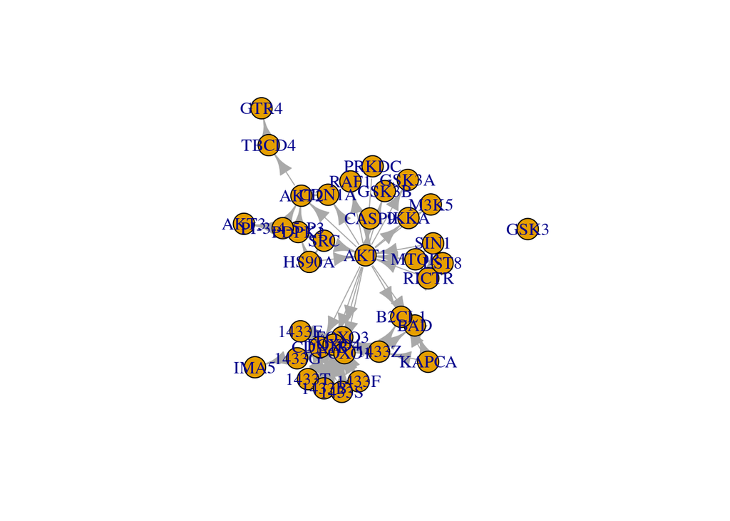

```r
## using ndexr to convert an RCX to an igraph object
graph = rcx_toNGraph(network)
## assigne the vertex names from the rcx node names
V(graph)$name = V(graph)$n
## visulize the igraph!
plot(graph)
```

a little bit more advanced

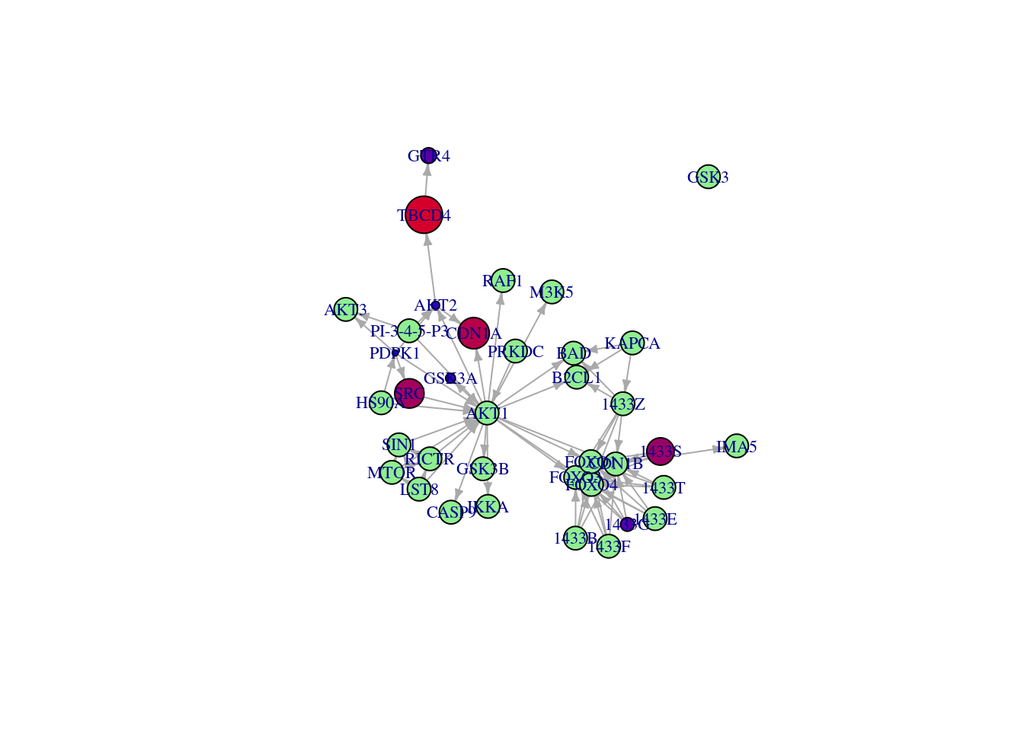

```r
## using ndexr to convert an RCX to an igraph object
graph = rcx_toNGraph(network)
## assigne the vertex names from the rcx node names
V(graph)$name = V(graph)$n
## map gene expression to vertices
nodeSize = merge(data.frame(name=V(graph)$name,stringsAsFactors = F),
                 geneRegulation[,c("Gene", "FoldChange")],
                 by.x = "name", by.y = "Gene", all.x = T)
## precalculation for the color
nodeSize$color = ifelse(is.na(nodeSize$FoldChange),
                         0,
                         as.integer((nodeSize$FoldChange^3)*120))
## assign color to vertices
V(graph)$color = ifelse(is.na(nodeSize$FoldChange),
                         "lightgreen",
                         rgb(nodeSize$color,0,255-nodeSize$color, maxColorValue = 255))
## adjust edge weight for force directed layout
E(graph)$weight = ifelse(E(graph)$i=="in-complex-with",1,2)
## visulize the igraph!
plot(graph,
     vertex.size = ifelse(is.na(nodeSize$FoldChange),12, as.integer(nodeSize$FoldChange^3*11)),
     vertex.label.cex = .7,
     edge.arrow.size=.4)
```

```r
nodes = data.frame(id=network$nodes$'@id',
                   name=network$nodes$n,
                   group=ifelse(network$nodes$n %in% geneRegulation$Gene,"changed","normal"),
                   stringsAsFactors = F)
edges = data.frame(source=network$edges$s,
                   target=network$edges$t,
                   id=network$edges$'@id',
                   interaction=network$edges$i,
                   stringsAsFactors = F)
## send the network to Cytoscape
network.suid <- createNetwork(nodes, edges, "FancyNetwork", "MyCollection")
```

```
## Network SUID is : 1238
## Applying default style
## Applying Error: can't find argument 'network' layout
```

```r
## add the gene regulation as table
loadTableData(geneRegulation,
              data.key.column = "Gene",
              table = "node",
              table.key.column = "name")
```

```
## [1] "Success: Data loaded in defaultnode table"
```

```r
## do some layout
style.name = "FancyStyle"
## default layout
defaults <- list(NODE_SHAPE="ROUND_RECTANGLE",
                 NODE_FILL_COLOR="lightgreen",
                 NODE_SIZE=30,
                 NODE_LABEL_FONT_SIZE=8,
                 EDGE_WIDTH=4,
                 EDGE_TARGET_ARROW_UNSELECTED_PAINT="#404040",
                 EDGE_TARGET_ARROW_SHAPE="delta")
## node-table:name is used as default node label
nodeLabels <- mapVisualProperty('node label','name','p')
## node shape for group "changed" is set to ellipse
nodeShape <- mapVisualProperty('node shape','group','d', c("changed"), c('ellipse'))
## node size and color, and label size is based on fold change
nodeSize <- mapVisualProperty('node size','FoldChange','c', c(0.7,1.5), c(40,100))
nodeFills <- mapVisualProperty('node fill color','FoldChange','c', c(0.7,1.0,1.5), c('#FF0000','#888888','#0000FF'))
nodeLabelFontSize <- mapVisualProperty('node label font size','FoldChange','c', c(0.7,1.5), c(11,29))

## edge arrow and color for "in-complex-with"
edgeArrowShape <- mapVisualProperty('edge target arrow shape','interaction','d', c("in-complex-with"), c('none'))
edgeColor <- mapVisualProperty('edge color','interaction','d', c("in-complex-with"), c('#FF4949'))

## create style with node attribute-fill mappings and some defaults
createStyle(style.name, defaults, list(nodeLabels,
                                       nodeSize,
                                       nodeFills,
                                       nodeLabelFontSize,
                                       nodeShape,
                                       edgeArrowShape,
                                       edgeColor))
## apply the stype to the network
applyStyle(style.name)
```

```
## [1] "Style applied to views:"   "FancyNetwork (SUID: 1359)"
```

```
## [1] "Output File: /home/rstudio/cytoscape.png"
```

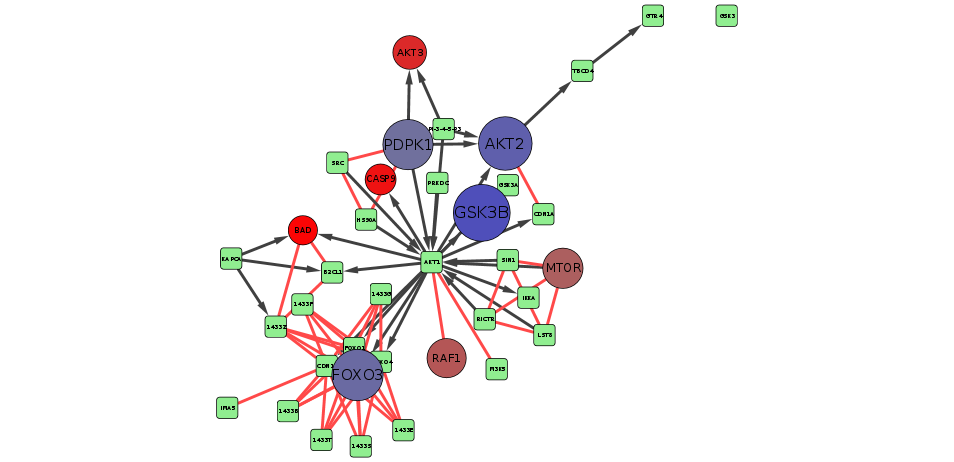

```r
## export as png
exportImage("cytoscape.png", "png")
```

# Send a new network to NDEx

```r
## get the new network
newNetwork <- createIgraphFromNetwork("FancyNetwork")

## convert to RCX
newRCX = ngraph_fromRCX(newNetwork)

## create a new network on NDEx
ndex_create_network(ndexcon, newRCX, )
```

# html visualization

```r
## get the nodes with label
nodes <- data.frame(id = network$nodes$'@id',
                    label = network$nodes$n)
## map the expression data on the nodes
nodeSize = merge(nodes, geneRegulation[,c("Gene", "FoldChange")],
                 by.x = "label", by.y = "Gene", all.x = T)
## assign size, shape, color and font (color)
nodes$value = ifelse(is.na(nodeSize$FoldChange),20, as.integer(nodeSize$FoldChange*50))
nodes$shape = ifelse(is.na(nodeSize$FoldChange),"box", "circle")
nodes$font = ifelse(is.na(nodeSize$FoldChange),"14px arial black", "14px arial white")
nodes$color = ifelse(is.na(nodeSize$FoldChange),
                     "lightgreen",
                     paste0("rgba(",as.integer(nodeSize$FoldChange^3*150),",0,",as.integer(255-(nodeSize$FoldChange^4*150)),",1)"))

## get edges
## filter neighbor relations
edgeFilter = (network$edges$i != "neighbor-of")
edges <- data.frame(from = network$edges[edgeFilter,]$s,
                    to = network$edges[edgeFilter,]$t,
                    group = network$edges[edgeFilter,]$i)
## assigne color, length and arrow heads
edges$color = ifelse(edges$group=="in-complex-with","red", "black")
edges$length = ifelse(edges$group=="in-complex-with",10 , 50)
edges$arrows = ifelse(edges$group=="in-complex-with","" , "to")

## visualize!
visNetwork(nodes, edges)
```

[interactive chart not shown]